# Sports Analytics (Regularization and DecisionTree based approaches for Regression problems)

Mohammad Ali Momen

05/06/2023

**Data Analysis methodology**: CRISP-DM

**Dataset**: Hitters dataset (Major League Baseball Data from the 1986 and 1987 seasons in US)

**Case Goal**: Annual Salary prediction of each Player in 1987 base on his performance in 1986

# 1 Required Libraries

```r
library('glmnet')
library('rpart')
library('rpart.plot')
library('randomForest')
```

# 2 Read Data from File

```r
load('case4_dataset_v1.RData')  # pre-processed Data
dim(data2)  # 263 records, 19 variables
```

```
## [1] 263  19
```

# 3 Business Understanding

- know business process and issues
- know the context of the problem
- know the order of numbers in the business

# 4 Data Understanding

## 4.1 Data Inspection

Data Understanding from Free Perspective

### 4.1.1 Dataset variables definition

```r
colnames(data2)
```

```
##  [1] "Hits"      "HmRun"     "Runs"      "RBI"       "Walks"     "Years"
##  [7] "CAtBat"    "CHits"     "CHmRun"    "CRuns"     "CRBI"      "CWalks"
## [13] "League"    "Division"  "PutOuts"   "Assists"   "Errors"    "Salary"
## [19] "NewLeague"
```

> KPI (Key Performance Indicator) variables in 1986
- **Hits**: Number of hits in 1986
- **HmRun**: Number of home runs in 1986
- **Runs**: Number of runs in 1986
- **RBI**: Number of runs batted in in 1986
- **Walks**: Number of walks in 1986
- **PutOuts**: Number of put outs in 1986
- **Assists**: Number of assists in 1986
- **Errors**: Number of errors in 1986

> KPI variables in whole career life
- **Years**: Number of years in the major leagues
- **CAtBat**: Number of times at bat during his career
- **CHits**: Number of hits during his career
- **CHmRun**: Number of home runs during his career
- **CRuns**: Number of runs during his career
- **CRBI**: Number of runs batted in during his career
- **CWalks**: Number of walks during his career

> Categorical variables
- **League**: A factor with levels A and N indicating player’s league at the end of 1986 (american league|national league)
- **Division**: A factor with levels E and W indicating player’s division at the end of 1986 (west|east)
- **NewLeague**: A factor with levels A and N indicating player’s league at the beginning of 1987
- **Name**: name of players

> Outcome variable
- **Salary**: 1987 annual salary on opening day in thousands of dollars

# 5 Data Exploring

Data Understanding from Statistical Perspective

### 5.0.1 Overview of Dataframe

```r
class(data2)
```

```
## [1] "data.frame"
```

```r
head(data2)
```

|  | Hits | HmRun | Runs | RBI | Walks | Years | CAtBat | CHits | CHmRun | CRuns | CRBI | CWalks | League | Division | PutOuts | Assists | Errors | Salary | NewLeague |
| --- | --- | --- | --- | --- | --- | --- | --- | --- | --- | --- | --- | --- | --- | --- | --- | --- | --- | --- | --- |
| 2 | 81 | 7 | 24 | 38 | 39 | 14 | 3449 | 835 | 69 | 321 | 414 | 375 | N | W | 632 | 43 | 10 | 475.0 | N |
| 3 | 130 | 18 | 66 | 72 | 76 | 3 | 1624 | 457 | 63 | 224 | 266 | 263 | A | W | 880 | 82 | 14 | 480.0 | A |
| 4 | 141 | 20 | 65 | 78 | 37 | 11 | 5628 | 1575 | 225 | 828 | 838 | 354 | N | E | 200 | 11 | 3 | 500.0 | N |
| 5 | 87 | 10 | 39 | 42 | 30 | 2 | 396 | 101 | 12 | 48 | 46 | 33 | N | E | 805 | 40 | 4 | 91.5 | N |
| 6 | 169 | 4 | 74 | 51 | 35 | 11 | 4408 | 1133 | 19 | 501 | 336 | 194 | A | W | 282 | 421 | 25 | 750.0 | A |
| 7 | 37 | 1 | 23 | 8 | 21 | 2 | 214 | 42 | 1 | 30 | 9 | 24 | N | E | 76 | 127 | 7 | 70.0 | A |

```r
tail(data2)
```

|  | Hits | HmRun | Runs | RBI | Walks | Years | CAtBat | CHits | CHmRun | CRuns | CRBI | CWalks | League | Division | PutOuts | Assists | Errors | Salary | NewLeague |
| --- | --- | --- | --- | --- | --- | --- | --- | --- | --- | --- | --- | --- | --- | --- | --- | --- | --- | --- | --- |
| 316 | 172 | 22 | 82 | 100 | 57 | 1 | 593 | 172 | 22 | 82 | 100 | 57 | A | W | 1222 | 139 | 15 | 165 | A |
| 318 | 127 | 7 | 65 | 48 | 37 | 5 | 2703 | 806 | 32 | 379 | 311 | 138 | N | E | 325 | 9 | 3 | 700 | N |
| 319 | 136 | 5 | 76 | 50 | 94 | 12 | 5511 | 1511 | 39 | 897 | 451 | 875 | A | E | 313 | 381 | 20 | 875 | A |
| 320 | 126 | 3 | 61 | 43 | 52 | 6 | 1700 | 433 | 7 | 217 | 93 | 146 | A | W | 37 | 113 | 7 | 385 | A |
| 321 | 144 | 9 | 85 | 60 | 78 | 8 | 3198 | 857 | 97 | 470 | 420 | 332 | A | E | 1314 | 131 | 12 | 960 | A |
| 322 | 170 | 9 | 77 | 44 | 31 | 11 | 4908 | 1457 | 30 | 775 | 357 | 249 | A | W | 408 | 4 | 3 | 1000 | A |

```r
str(data2)
```

```
## 'data.frame':    263 obs. of  19 variables:
##  $ Hits     : int  81 130 141 87 169 37 73 81 92 159 ...
##  $ HmRun    : int  7 18 20 10 4 1 0 6 17 21 ...
##  $ Runs     : int  24 66 65 39 74 23 24 26 49 107 ...
##  $ RBI      : int  38 72 78 42 51 8 24 32 66 75 ...
##  $ Walks    : int  39 76 37 30 35 21 7 8 65 59 ...
##  $ Years    : int  14 3 11 2 11 2 3 2 13 10 ...
##  $ CAtBat   : int  3449 1624 5628 396 4408 214 509 341 5206 4631 ...
##  $ CHits    : int  835 457 1575 101 1133 42 108 86 1332 1300 ...
##  $ CHmRun   : int  69 63 225 12 19 1 0 6 253 90 ...
##  $ CRuns    : int  321 224 828 48 501 30 41 32 784 702 ...
##  $ CRBI     : int  414 266 838 46 336 9 37 34 890 504 ...
##  $ CWalks   : int  375 263 354 33 194 24 12 8 866 488 ...
##  $ League   : Factor w/ 2 levels "A","N": 2 1 2 2 1 2 1 2 1 1 ...
##  $ Division : Factor w/ 2 levels "E","W": 2 2 1 1 2 1 2 2 1 1 ...
##  $ PutOuts  : int  632 880 200 805 282 76 121 143 0 238 ...
##  $ Assists  : int  43 82 11 40 421 127 283 290 0 445 ...
##  $ Errors   : int  10 14 3 4 25 7 9 19 0 22 ...
##  $ Salary   : num  475 480 500 91.5 750 ...
##  $ NewLeague: Factor w/ 2 levels "A","N": 2 1 2 2 1 1 1 2 1 1 ...
```

```r
summary(data2)
```

```
##       Hits           HmRun            Runs             RBI
##  Min.   :  1.0   Min.   : 0.00   Min.   :  0.00   Min.   :  0.00
##  1st Qu.: 71.5   1st Qu.: 5.00   1st Qu.: 33.50   1st Qu.: 30.00
##  Median :103.0   Median : 9.00   Median : 52.00   Median : 47.00
##  Mean   :107.8   Mean   :11.62   Mean   : 54.75   Mean   : 51.49
##  3rd Qu.:141.5   3rd Qu.:18.00   3rd Qu.: 73.00   3rd Qu.: 71.00
##  Max.   :238.0   Max.   :40.00   Max.   :130.00   Max.   :121.00
##      Walks            Years            CAtBat            CHits
##  Min.   :  0.00   Min.   : 1.000   Min.   :   19.0   Min.   :   4.0
##  1st Qu.: 23.00   1st Qu.: 4.000   1st Qu.:  842.5   1st Qu.: 212.0
##  Median : 37.00   Median : 6.000   Median : 1931.0   Median : 516.0
##  Mean   : 41.11   Mean   : 7.312   Mean   : 2657.5   Mean   : 722.2
##  3rd Qu.: 57.00   3rd Qu.:10.000   3rd Qu.: 3890.5   3rd Qu.:1054.0
##  Max.   :105.00   Max.   :24.000   Max.   :14053.0   Max.   :4256.0
##      CHmRun           CRuns             CRBI            CWalks       League
##  Min.   :  0.00   Min.   :   2.0   Min.   :   3.0   Min.   :   1.0   A:139
##  1st Qu.: 15.00   1st Qu.: 105.5   1st Qu.:  95.0   1st Qu.:  71.0   N:124
##  Median : 40.00   Median : 250.0   Median : 230.0   Median : 174.0
##  Mean   : 69.24   Mean   : 361.2   Mean   : 330.4   Mean   : 260.3
##  3rd Qu.: 92.50   3rd Qu.: 497.5   3rd Qu.: 424.5   3rd Qu.: 328.5
##  Max.   :548.00   Max.   :2165.0   Max.   :1659.0   Max.   :1566.0
##  Division    PutOuts          Assists          Errors           Salary
##  E:129    Min.   :   0.0   Min.   :  0.0   Min.   : 0.000   Min.   :  67.5
##  W:134    1st Qu.: 113.5   1st Qu.:  8.0   1st Qu.: 3.000   1st Qu.: 190.0
##           Median : 224.0   Median : 45.0   Median : 7.000   Median : 425.0
##           Mean   : 290.7   Mean   :118.8   Mean   : 8.593   Mean   : 535.9
##           3rd Qu.: 322.5   3rd Qu.:192.0   3rd Qu.:13.000   3rd Qu.: 750.0
##           Max.   :1377.0   Max.   :492.0   Max.   :32.000   Max.   :2460.0
##  NewLeague
##  A:141
##  N:122
##
##
##
##
```

# 6 Data PreProcessing

## 6.1 Divide Dataset into Train and Test randomly

```r
head(train)
```

|  | Hits | HmRun | Runs | RBI | Walks | Years | CAtBat | CHits | CHmRun | CRuns | CRBI | CWalks | League | Division | PutOuts | Assists | Errors | Salary | NewLeague | Log_Salary |
| --- | --- | --- | --- | --- | --- | --- | --- | --- | --- | --- | --- | --- | --- | --- | --- | --- | --- | --- | --- | --- |
| 132 | 54 | 10 | 30 | 39 | 31 | 5 | 1185 | 299 | 40 | 145 | 154 | 128 | N | E | 50 | 136 | 20 | 297.5 | N | 5.695414 |
| 143 | 55 | 9 | 34 | 23 | 45 | 12 | 4405 | 1213 | 194 | 702 | 705 | 625 | N | E | 623 | 35 | 3 | 1300.0 | N | 7.170120 |
| 171 | 91 | 12 | 41 | 42 | 57 | 13 | 5590 | 1397 | 83 | 578 | 579 | 644 | A | W | 686 | 46 | 4 | 825.0 | N | 6.715383 |
| 129 | 158 | 15 | 70 | 84 | 42 | 5 | 2358 | 636 | 58 | 265 | 316 | 134 | N | E | 331 | 20 | 4 | 662.5 | N | 6.496021 |
| 134 | 99 | 1 | 46 | 24 | 29 | 4 | 618 | 129 | 1 | 72 | 31 | 48 | A | W | 278 | 415 | 16 | 87.5 | A | 4.471639 |
| 266 | 57 | 8 | 32 | 25 | 18 | 3 | 653 | 170 | 17 | 98 | 54 | 62 | N | E | 42 | 94 | 13 | 140.0 | N | 4.941642 |

```r
dim(train)  # 18 predictor variables
```

```
## [1] 210  20
```

```r
str(train)
```

```
## 'data.frame':    210 obs. of  20 variables:
##  $ Hits      : int  54 55 91 158 99 57 85 123 154 90 ...
##  $ HmRun     : int  10 9 12 15 1 8 3 27 22 11 ...
##  $ Runs      : int  30 34 41 70 46 32 30 76 76 50 ...
##  $ RBI       : int  39 23 42 84 24 25 44 93 84 45 ...
##  $ Walks     : int  31 45 57 42 29 18 20 72 43 43 ...
##  $ Years     : int  5 12 13 5 4 3 8 4 14 10 ...
##  $ CAtBat    : int  1185 4405 5590 2358 618 653 2140 1810 6100 2288 ...
##  $ CHits     : int  299 1213 1397 636 129 170 568 471 1583 614 ...
##  $ CHmRun    : int  40 194 83 58 1 17 16 108 131 43 ...
##  $ CRuns     : int  145 702 578 265 72 98 216 292 743 295 ...
##  $ CRBI      : int  154 705 579 316 31 54 208 343 693 273 ...
##  $ CWalks    : int  128 625 644 134 48 62 93 267 300 269 ...
##  $ League    : Factor w/ 2 levels "A","N": 2 2 1 2 1 2 1 2 1 1 ...
##  $ Division  : Factor w/ 2 levels "E","W": 1 1 2 1 2 1 1 1 2 1 ...
##  $ PutOuts   : int  50 623 686 331 278 42 91 226 316 60 ...
##  $ Assists   : int  136 35 46 20 415 94 185 10 439 176 ...
##  $ Errors    : int  20 3 4 4 16 13 12 6 10 6 ...
##  $ Salary    : num  297.5 1300 825 662.5 87.5 ...
##  $ NewLeague : Factor w/ 2 levels "A","N": 2 2 2 2 1 2 1 2 1 1 ...
##  $ Log_Salary: num  5.7 7.17 6.72 6.5 4.47 ...
```

```r
head(test)
```

|  | Hits | HmRun | Runs | RBI | Walks | Years | CAtBat | CHits | CHmRun | CRuns | CRBI | CWalks | League | Division | PutOuts | Assists | Errors | Salary | NewLeague |
| --- | --- | --- | --- | --- | --- | --- | --- | --- | --- | --- | --- | --- | --- | --- | --- | --- | --- | --- | --- |
| 2 | 81 | 7 | 24 | 38 | 39 | 14 | 3449 | 835 | 69 | 321 | 414 | 375 | N | W | 632 | 43 | 10 | 475 | N |
| 6 | 169 | 4 | 74 | 51 | 35 | 11 | 4408 | 1133 | 19 | 501 | 336 | 194 | A | W | 282 | 421 | 25 | 750 | A |
| 14 | 60 | 0 | 30 | 11 | 22 | 6 | 1941 | 510 | 4 | 309 | 103 | 207 | A | E | 121 | 151 | 6 | 700 | A |
| 18 | 46 | 2 | 24 | 8 | 15 | 5 | 479 | 102 | 5 | 65 | 23 | 39 | A | W | 102 | 177 | 16 | 175 | A |
| 28 | 129 | 10 | 50 | 56 | 40 | 10 | 2331 | 604 | 61 | 246 | 327 | 166 | N | W | 732 | 83 | 13 | 750 | N |
| 32 | 108 | 6 | 55 | 36 | 22 | 3 | 591 | 149 | 8 | 80 | 46 | 31 | N | W | 226 | 7 | 4 | 110 | N |

```r
dim(test)
```

```
## [1] 53 19
```

```r
str(test)
```

```
## 'data.frame':    53 obs. of  19 variables:
##  $ Hits     : int  81 169 60 46 129 108 41 68 78 177 ...
##  $ HmRun    : int  7 4 0 2 10 6 1 2 6 25 ...
##  $ Runs     : int  24 74 30 24 50 55 15 28 32 98 ...
##  $ RBI      : int  38 51 11 8 56 36 21 26 41 81 ...
##  $ Walks    : int  39 35 22 15 40 22 33 22 12 70 ...
##  $ Years    : int  14 11 6 5 10 3 2 6 12 6 ...
##  $ CAtBat   : int  3449 4408 1941 479 2331 591 232 999 3742 3210 ...
##  $ CHits    : int  835 1133 510 102 604 149 50 236 968 927 ...
##  $ CHmRun   : int  69 19 4 5 61 8 4 21 35 133 ...
##  $ CRuns    : int  321 501 309 65 246 80 20 108 409 529 ...
##  $ CRBI     : int  414 336 103 23 327 46 29 117 321 472 ...
##  $ CWalks   : int  375 194 207 39 166 31 45 118 170 313 ...
##  $ League   : Factor w/ 2 levels "A","N": 2 1 1 1 2 2 1 1 2 1 ...
##  $ Division : Factor w/ 2 levels "E","W": 2 2 1 2 2 2 1 1 2 1 ...
##  $ PutOuts  : int  632 282 121 102 732 226 326 359 106 240 ...
##  $ Assists  : int  43 421 151 177 83 7 29 30 206 482 ...
##  $ Errors   : int  10 25 6 16 13 4 5 4 7 13 ...
##  $ Salary   : num  475 750 700 175 750 ...
##  $ NewLeague: Factor w/ 2 levels "A","N": 2 1 1 1 2 2 1 1 2 1 ...
```

# 7 Modeling

Results of 4 created models:

1. Linear Regression with all 18 variables
2. BestSubSelection base on statistical indexes (BIC, CP, Adjusted-R2)
3. BestSubSelection base on k-fold cross validation
4. BestSubSelection with trimmed data

```r
models_comp  # models comparison
```

|  | Mean.of.AbsErrors | Median.of.AbsErrors | SD.of.AbsErrors | IQR.of.AbsErrors | Min.of.AbsErrors | Max.of.AbsErrors |
| --- | --- | --- | --- | --- | --- | --- |
| LM | 237.4351 | 182.5055 | 220.8587 | 255.3140 | 0.08237289 | 831.5086 |
| BestSub | 246.9167 | 181.9413 | 237.4687 | 207.2769 | 0.90210710 | 945.0831 |
| BestSubCV | 233.5006 | 169.5449 | 233.3134 | 177.0159 | 2.31135988 | 935.5373 |
| TrimmedBestSub | 242.5957 | 172.5117 | 235.7795 | 252.5046 | 2.14943889 | 847.3258 |

## 7.1 Model 5: Ridge Regression

```r
x <- model.matrix(Log_Salary ~ . - Salary, data = train)[,-1]  # remove intercept
y <- train$Log_Salary

lambda_ridge_grid <- 10 ^ seq(10, -2, length.out = 100)
lambda_ridge_grid
```

```
##   [1] 1.000000e+10 7.564633e+09 5.722368e+09 4.328761e+09 3.274549e+09
##   [6] 2.477076e+09 1.873817e+09 1.417474e+09 1.072267e+09 8.111308e+08
##  [11] 6.135907e+08 4.641589e+08 3.511192e+08 2.656088e+08 2.009233e+08
##  [16] 1.519911e+08 1.149757e+08 8.697490e+07 6.579332e+07 4.977024e+07
##  [21] 3.764936e+07 2.848036e+07 2.154435e+07 1.629751e+07 1.232847e+07
##  [26] 9.326033e+06 7.054802e+06 5.336699e+06 4.037017e+06 3.053856e+06
##  [31] 2.310130e+06 1.747528e+06 1.321941e+06 1.000000e+06 7.564633e+05
##  [36] 5.722368e+05 4.328761e+05 3.274549e+05 2.477076e+05 1.873817e+05
##  [41] 1.417474e+05 1.072267e+05 8.111308e+04 6.135907e+04 4.641589e+04
##  [46] 3.511192e+04 2.656088e+04 2.009233e+04 1.519911e+04 1.149757e+04
##  [51] 8.697490e+03 6.579332e+03 4.977024e+03 3.764936e+03 2.848036e+03
##  [56] 2.154435e+03 1.629751e+03 1.232847e+03 9.326033e+02 7.054802e+02
##  [61] 5.336699e+02 4.037017e+02 3.053856e+02 2.310130e+02 1.747528e+02
##  [66] 1.321941e+02 1.000000e+02 7.564633e+01 5.722368e+01 4.328761e+01
##  [71] 3.274549e+01 2.477076e+01 1.873817e+01 1.417474e+01 1.072267e+01
##  [76] 8.111308e+00 6.135907e+00 4.641589e+00 3.511192e+00 2.656088e+00
##  [81] 2.009233e+00 1.519911e+00 1.149757e+00 8.697490e-01 6.579332e-01
##  [86] 4.977024e-01 3.764936e-01 2.848036e-01 2.154435e-01 1.629751e-01
##  [91] 1.232847e-01 9.326033e-02 7.054802e-02 5.336699e-02 4.037017e-02
##  [96] 3.053856e-02 2.310130e-02 1.747528e-02 1.321941e-02 1.000000e-02
```

```r
ridgereg_1 <- glmnet::glmnet(x, y, alpha = 0, lambda = lambda_ridge_grid)
dim(coef(ridgereg_1))  # 19 coefficients (18 predictors + 1 intercept) in 100 iteration (different lambdas)
```

```
## [1]  19 100
```

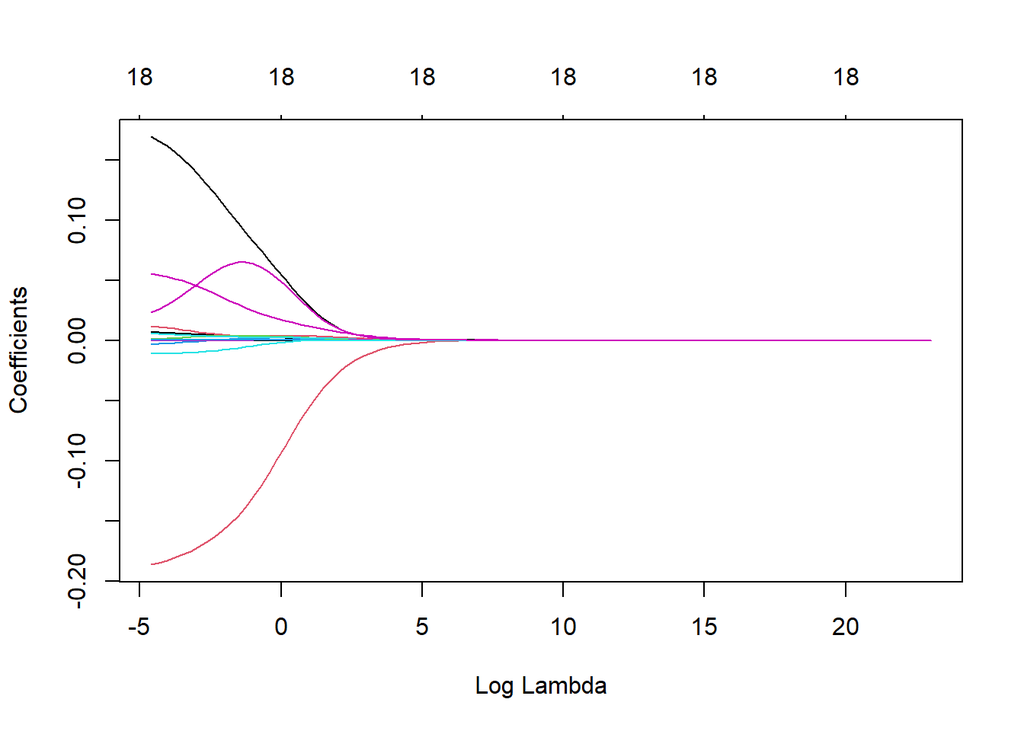

```r
plot(ridgereg_1, xvar = 'lambda')  # plot Regression Coefficients vs. Log lambda
```

```r
ridgereg_1$lambda[50]  # lambda value with index 50
```

```
## [1] 11497.57
```

```r
coef(ridgereg_1)[,50]  # retrieve one of Regressions Coefficients (Regression Coefficients for lambda 11497.57)
```

```
##   (Intercept)          Hits         HmRun          Runs           RBI
##  5.939357e+00  8.444237e-07  3.184666e-06  1.374395e-06  1.370335e-06
##         Walks         Years        CAtBat         CHits        CHmRun
##  1.415395e-06  8.695355e-06  2.045461e-08  7.210466e-08  4.955790e-07
##         CRuns          CRBI        CWalks       LeagueN     DivisionW
##  1.408903e-07  1.443128e-07  1.543527e-07  3.658080e-06 -2.448081e-05
##       PutOuts       Assists        Errors    NewLeagueN
##  6.869789e-08  1.864747e-08 -6.919176e-08  3.218910e-06
```

k-fold cross validation approach to choose the best model (select the best lambda)

```r
set.seed(1234)
ridge_cv <- cv.glmnet(x, y, alpha = 0, nfolds = 10, lambda = lambda_ridge_grid)
ridge_cv
```

```
##
## Call:  cv.glmnet(x = x, y = y, lambda = lambda_ridge_grid, nfolds = 10,      alpha = 0)
##
## Measure: Mean-Squared Error
##
##     Lambda Index Measure      SE Nonzero
## min 0.3765    87  0.3911 0.04857      18
## 1se 2.6561    80  0.4292 0.03788      18
```

```r
ridge_cv$cvm  # the mean cross-validated error (per every lambda)
```

```
##   [1] 0.8352461 0.8352461 0.8352461 0.8352461 0.8352461 0.8352461 0.8352461
##   [8] 0.8352461 0.8352461 0.8352461 0.8352461 0.8352461 0.8352461 0.8352461
##  [15] 0.8352461 0.8352461 0.8352461 0.8352461 0.8352460 0.8352460 0.8352460
##  [22] 0.8352459 0.8352459 0.8352458 0.8352457 0.8352455 0.8352453 0.8352451
##  [29] 0.8352447 0.8352443 0.8352437 0.8352429 0.8352419 0.8352405 0.8352387
##  [36] 0.8352363 0.8352331 0.8352289 0.8352233 0.8352160 0.8352063 0.8351935
##  [43] 0.8351765 0.8351541 0.8351245 0.8350854 0.8350337 0.8349653 0.8348749
##  [50] 0.8347555 0.8345977 0.8343893 0.8341139 0.8337503 0.8332702 0.8326367
##  [57] 0.8318013 0.8307002 0.8292507 0.8273448 0.8248432 0.8215890 0.8173273
##  [64] 0.8117909 0.8046377 0.7954606 0.7837946 0.7691385 0.7510004 0.7289747
##  [71] 0.7028531 0.6727539 0.6392539 0.6034512 0.5669159 0.5314866 0.4989363
##  [78] 0.4706481 0.4473814 0.4292183 0.4156962 0.4060969 0.3995473 0.3953061
##  [85] 0.3927736 0.3914599 0.3910822 0.3913981 0.3922623 0.3935525 0.3951956
##  [92] 0.3970365 0.3991528 0.4011515 0.4034684 0.4054181 0.4077326 0.4095850
##  [99] 0.4117368 0.4135256
```

```r
ridge_cv$cvsd  # estimate of standard deviation error of cvm
```

```
##   [1] 0.06577608 0.06577608 0.06577608 0.06577608 0.06577608 0.06577608
##   [7] 0.06577608 0.06577608 0.06577608 0.06577608 0.06577608 0.06577608
##  [13] 0.06577608 0.06577608 0.06577608 0.06577608 0.06577607 0.06577607
##  [19] 0.06577607 0.06577607 0.06577607 0.06577606 0.06577606 0.06577605
##  [25] 0.06577605 0.06577604 0.06577602 0.06577601 0.06577598 0.06577595
##  [31] 0.06577591 0.06577586 0.06577579 0.06577570 0.06577558 0.06577542
##  [37] 0.06577521 0.06577493 0.06577456 0.06577407 0.06577342 0.06577257
##  [43] 0.06577144 0.06576994 0.06576797 0.06576536 0.06576191 0.06575734
##  [49] 0.06575132 0.06574335 0.06573282 0.06571891 0.06570053 0.06567625
##  [55] 0.06564420 0.06560188 0.06554603 0.06547239 0.06537535 0.06524761
##  [61] 0.06507969 0.06486073 0.06457324 0.06419842 0.06371185 0.06308373
##  [67] 0.06227878 0.06125687 0.05997507 0.05839184 0.05647439 0.05420915
##  [73] 0.05161706 0.04877098 0.04581255 0.04296163 0.04049933 0.03871849
##  [79] 0.03783199 0.03788432 0.03873799 0.04014480 0.04184745 0.04364269
##  [85] 0.04540023 0.04705165 0.04856622 0.04995442 0.05122520 0.05240628
##  [91] 0.05352062 0.05456641 0.05559884 0.05654645 0.05751327 0.05836406
##  [97] 0.05924952 0.06000260 0.06077798 0.06145322
```

```r
ridge_cv$lambda.min  # value of lambda that gives the minimum cvm
```

```
## [1] 0.3764936
```

```r
ridgereg_2 <- glmnet(x, y, alpha = 0, lambda = ridge_cv$lambda.min)
coef(ridgereg_2)  # coefficients of regression with best lambda value
```

```
## 19 x 1 sparse Matrix of class "dgCMatrix"
##                        s0
## (Intercept)  4.575650e+00
## Hits         3.094534e-03
## HmRun        3.363272e-03
## Runs         3.601760e-03
## RBI          1.731321e-03
## Walks        2.446070e-03
## Years        2.428065e-02
## CAtBat       3.963196e-05
## CHits        1.432807e-04
## CHmRun       3.513587e-04
## CRuns        2.305884e-04
## CRBI         1.851250e-04
## CWalks       7.866778e-05
## LeagueN      8.197781e-02
## DivisionW   -1.302390e-01
## PutOuts      1.628322e-04
## Assists      2.044815e-04
## Errors      -4.480580e-03
## NewLeagueN   6.343312e-02
```

## 7.2 Model 6: LASSO Regression

```r
lassoreg_1 <- glmnet(x, y, alpha = 1, lambda = lambda_ridge_grid)
dim(coef(lassoreg_1))
```

```
## [1]  19 100
```

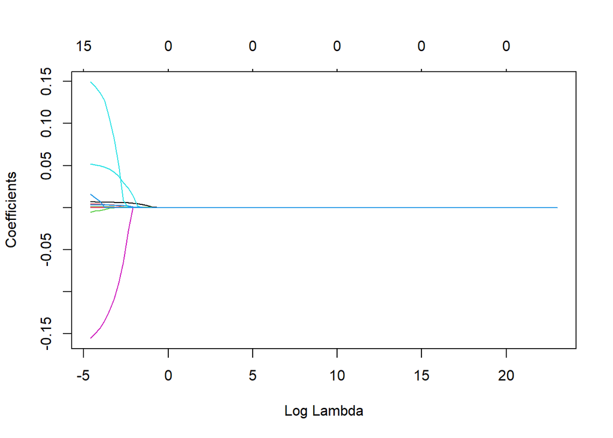

```r
plot(lassoreg_1, xvar = 'lambda')  # plot Regression Coefficients vs. Log lambda
```

```r
lassoreg_1$lambda[90]  # lambda value with index 90
```

```
## [1] 0.1629751
```

```r
coef(lassoreg_1)[,90]  # retrieve one of Regression Coefficients (Regression Coefficients for lambda 0.1629751
```

```
##  (Intercept)         Hits        HmRun         Runs          RBI        Walks
## 4.990673e+00 4.723891e-03 0.000000e+00 0.000000e+00 0.000000e+00 2.406145e-04
##        Years       CAtBat        CHits       CHmRun        CRuns         CRBI
## 1.933916e-03 9.615190e-05 1.633683e-06 0.000000e+00 2.944546e-04 1.692719e-04
##       CWalks      LeagueN    DivisionW      PutOuts      Assists       Errors
## 0.000000e+00 0.000000e+00 0.000000e+00 0.000000e+00 0.000000e+00 0.000000e+00
##   NewLeagueN
## 0.000000e+00
```

k-fold cross validation approach to choose the best model (select the best lambda)

```r
set.seed(1234)
lasso_cv <- cv.glmnet(x, y, alpha = 1, nfolds = 10, lambda = lambda_ridge_grid)

lasso_cv$cvm  # the mean cross-validated error (per every lambda)
```

```
##   [1] 0.8352461 0.8352461 0.8352461 0.8352461 0.8352461 0.8352461 0.8352461
##   [8] 0.8352461 0.8352461 0.8352461 0.8352461 0.8352461 0.8352461 0.8352461
##  [15] 0.8352461 0.8352461 0.8352461 0.8352461 0.8352461 0.8352461 0.8352461
##  [22] 0.8352461 0.8352461 0.8352461 0.8352461 0.8352461 0.8352461 0.8352461
##  [29] 0.8352461 0.8352461 0.8352461 0.8352461 0.8352461 0.8352461 0.8352461
##  [36] 0.8352461 0.8352461 0.8352461 0.8352461 0.8352461 0.8352461 0.8352461
##  [43] 0.8352461 0.8352461 0.8352461 0.8352461 0.8352461 0.8352461 0.8352461
##  [50] 0.8352461 0.8352461 0.8352461 0.8352461 0.8352461 0.8352461 0.8352461
##  [57] 0.8352461 0.8352461 0.8352461 0.8352461 0.8352461 0.8352461 0.8352461
##  [64] 0.8352461 0.8352461 0.8352461 0.8352461 0.8352461 0.8352461 0.8352461
##  [71] 0.8352461 0.8352461 0.8352461 0.8352461 0.8352461 0.8352461 0.8352461
##  [78] 0.8352461 0.8352461 0.8352461 0.8352461 0.8352461 0.8352461 0.8352461
##  [85] 0.8352461 0.7330581 0.6265707 0.5342484 0.4827698 0.4561076 0.4386057
##  [92] 0.4289658 0.4210471 0.4134569 0.4086189 0.4055083 0.4034783 0.4020251
##  [99] 0.4018536 0.4022715
```

```r
lasso_cv$cvsd  # estimate of standard deviation error of cvm
```

```
##   [1] 0.06577608 0.06577608 0.06577608 0.06577608 0.06577608 0.06577608
##   [7] 0.06577608 0.06577608 0.06577608 0.06577608 0.06577608 0.06577608
##  [13] 0.06577608 0.06577608 0.06577608 0.06577608 0.06577608 0.06577608
##  [19] 0.06577608 0.06577608 0.06577608 0.06577608 0.06577608 0.06577608
##  [25] 0.06577608 0.06577608 0.06577608 0.06577608 0.06577608 0.06577608
##  [31] 0.06577608 0.06577608 0.06577608 0.06577608 0.06577608 0.06577608
##  [37] 0.06577608 0.06577608 0.06577608 0.06577608 0.06577608 0.06577608
##  [43] 0.06577608 0.06577608 0.06577608 0.06577608 0.06577608 0.06577608
##  [49] 0.06577608 0.06577608 0.06577608 0.06577608 0.06577608 0.06577608
##  [55] 0.06577608 0.06577608 0.06577608 0.06577608 0.06577608 0.06577608
##  [61] 0.06577608 0.06577608 0.06577608 0.06577608 0.06577608 0.06577608
##  [67] 0.06577608 0.06577608 0.06577608 0.06577608 0.06577608 0.06577608
##  [73] 0.06577608 0.06577608 0.06577608 0.06577608 0.06577608 0.06577608
##  [79] 0.06577608 0.06577608 0.06577608 0.06577608 0.06577608 0.06577608
##  [85] 0.06577608 0.06231714 0.05562815 0.04699203 0.04352755 0.04347073
##  [91] 0.04553599 0.04814779 0.05062624 0.05253641 0.05375067 0.05489132
##  [97] 0.05574509 0.05639298 0.05681152 0.05710445
```

```r
lasso_cv$lambda.min  # value of lambda that gives the minimum cvm
```

```
## [1] 0.01321941
```

```r
lassoreg_2 <- glmnet(x, y, alpha = 1, lambda = lasso_cv$lambda.min)
coef(lassoreg_2)  # coefficients of regression with best lambda value
```

```
## 19 x 1 sparse Matrix of class "dgCMatrix"
##                        s0
## (Intercept)  4.349785e+00
## Hits         6.690111e-03
## HmRun        4.356618e-03
## Runs         7.872788e-04
## RBI          .
## Walks        3.160346e-03
## Years        5.011728e-02
## CAtBat       6.327267e-05
## CHits        1.286447e-04
## CHmRun       2.166499e-04
## CRuns        2.702136e-05
## CRBI         .
## CWalks       .
## LeagueN      1.438411e-01
## DivisionW   -1.501667e-01
## PutOuts      1.331674e-04
## Assists      .
## Errors      -4.134079e-03
## NewLeagueN   1.149787e-02
```

## 7.3 Model 7: Decision Tree

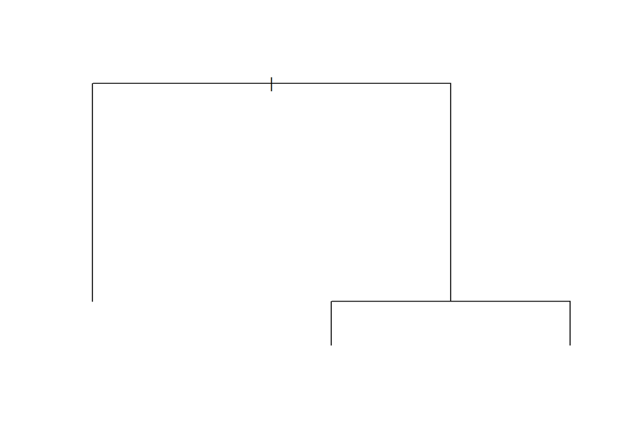

```r
tree_1 <- rpart(Log_Salary ~ Years + Hits + League, data = train, cp = 0.1, maxdepth = 3)
plot(tree_1)
```

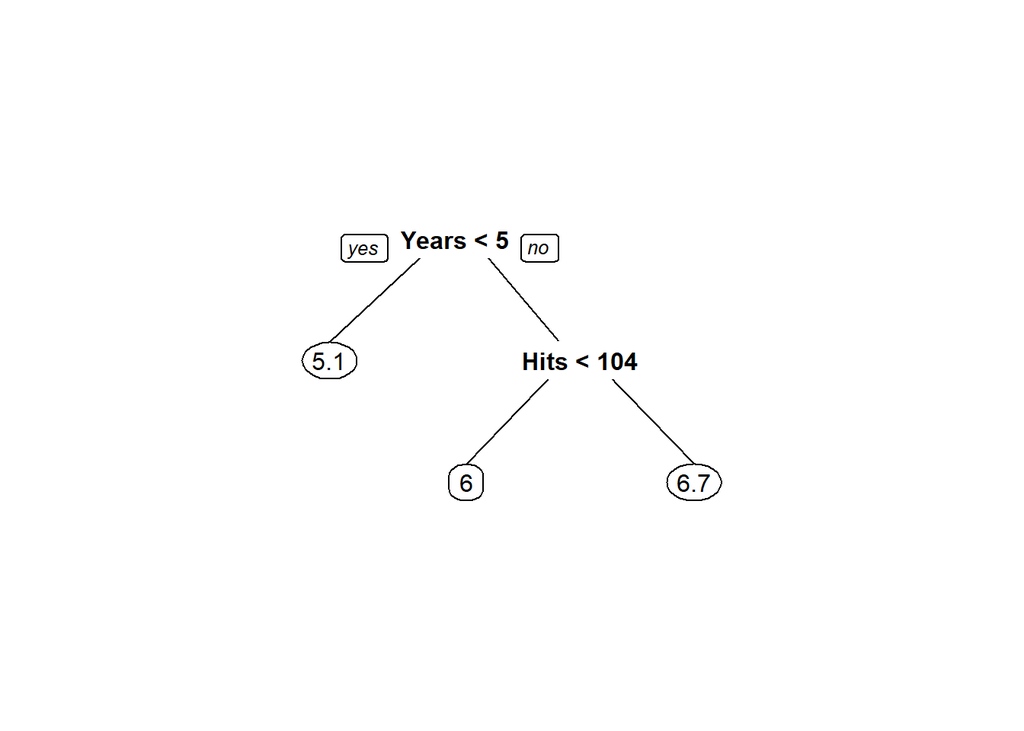

```r
rpart.plot::prp(tree_1)  # plot the tree
```

```r
tree_1
```

```
## n= 210
##
## node), split, n, deviance, yval
##       * denotes terminal node
##
## 1) root 210 173.70640 5.940042
##   2) Years< 4.5 75  33.97576 5.068033 *
##   3) Years>=4.5 135  51.01738 6.424491
##     6) Hits< 103.5 58  18.32600 6.004009 *
##     7) Hits>=103.5 77  14.71237 6.741218 *
```

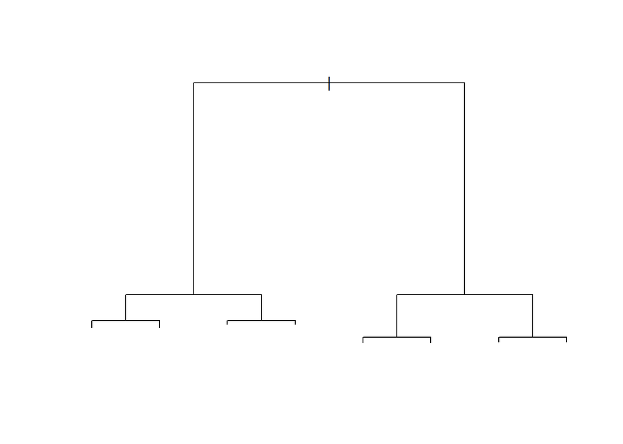

```r
tree_2 <- rpart(Log_Salary ~ Years + Hits + League, data = train, cp = 0.001, maxdepth = 3)
plot(tree_2)
```

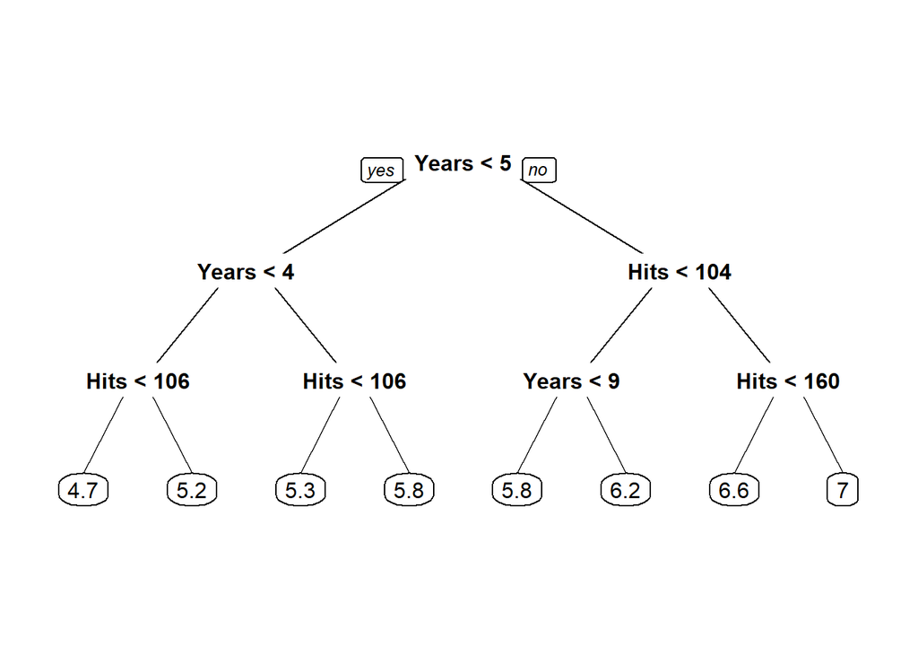

```r
rpart.plot::prp(tree_2)
```

```r
tree_2
```

```
## n= 210
##
## node), split, n, deviance, yval
##       * denotes terminal node
##
##  1) root 210 173.706400 5.940042
##    2) Years< 4.5 75  33.975760 5.068033
##      4) Years< 3.5 50  16.341920 4.832017
##        8) Hits< 105.5 33  11.654630 4.656013 *
##        9) Hits>=105.5 17   1.680648 5.173673 *
##      5) Years>=3.5 25   9.278333 5.540064
##       10) Hits< 106 13   1.746329 5.299820 *
##       11) Hits>=106 12   5.968830 5.800328 *
##    3) Years>=4.5 135  51.017380 6.424491
##      6) Hits< 103.5 58  18.326000 6.004009
##       12) Years< 8.5 26   6.723915 5.783633 *
##       13) Years>=8.5 32   9.313428 6.183065 *
##      7) Hits>=103.5 77  14.712370 6.741218
##       14) Hits< 159.5 54   9.134513 6.642284 *
##       15) Hits>=159.5 23   3.808373 6.973497 *
```

Which cp gives minimum Errors in Train dataset?

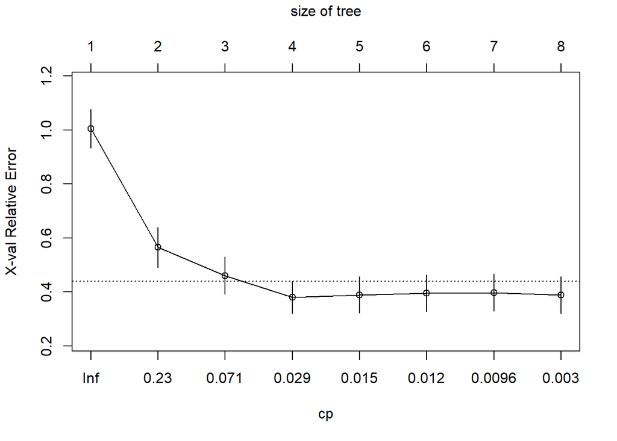

```r
plotcp(tree_2)
```

```r
tree_2$cptable
```

```
##            CP nsplit rel error    xerror       xstd
## 1 0.510708145      0 1.0000000 1.0041711 0.07171228
## 2 0.103502232      1 0.4892919 0.5652384 0.07393746
## 3 0.048101299      2 0.3857896 0.4603946 0.06871769
## 4 0.017308799      3 0.3376883 0.3795172 0.05965666
## 5 0.013175451      4 0.3203795 0.3893788 0.06759758
## 6 0.010186646      5 0.3072041 0.3955546 0.06838559
## 7 0.008998942      6 0.2970174 0.3979578 0.06827727
## 8 0.001000000      7 0.2880185 0.3882623 0.06773217
```

```r
tree_2$cptable[which.min(tree_2$cptable[,'xerror'])]
```

```
## [1] 0.0173088
```

Prune the complex Tree

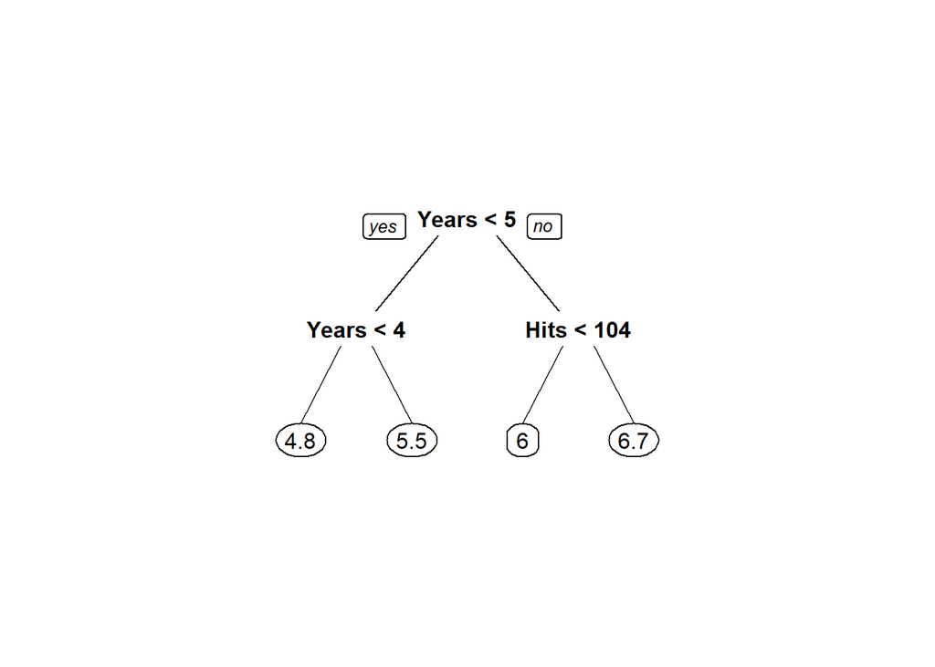

```r
tree_3 <- prune.rpart(tree_2, cp = tree_2$cptable[which.min(tree_2$cptable[,'xerror'])])  # prune tree_2 base on cp being equal to 0.0173088
prp(tree_3)  # plot the pruned tree
```

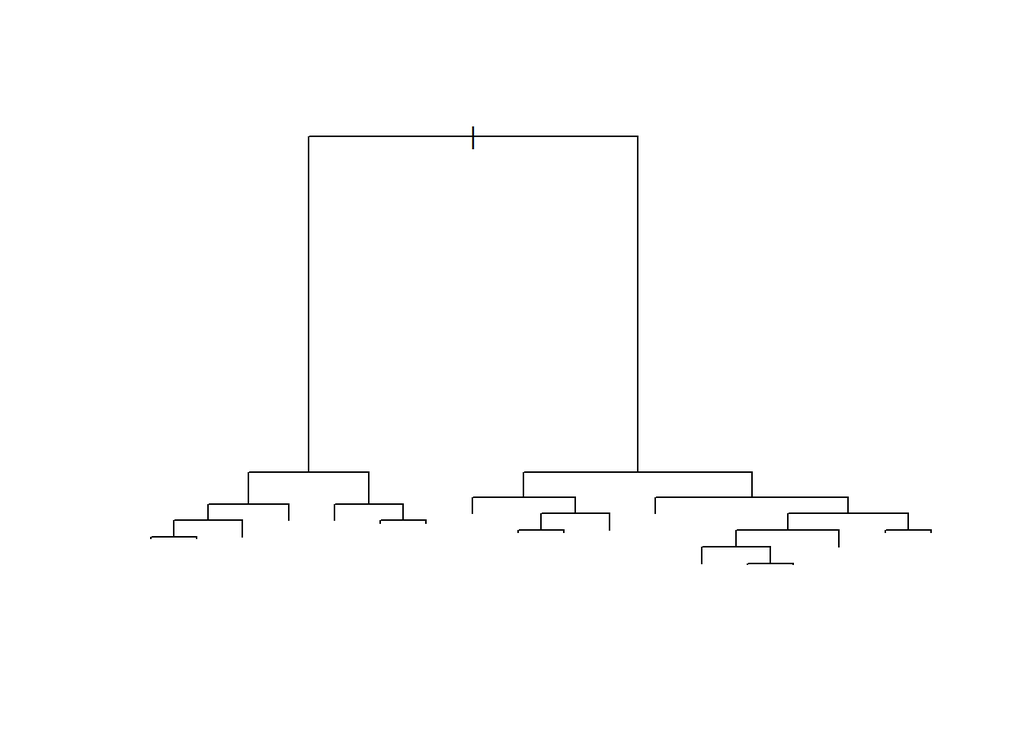

```r
tree_4 <- rpart(formula = Log_Salary ~ . - Salary, data = train, cp = 0.0001, maxdepth = 20)  # Decision Tree model using all variables
plot(tree_4)
```

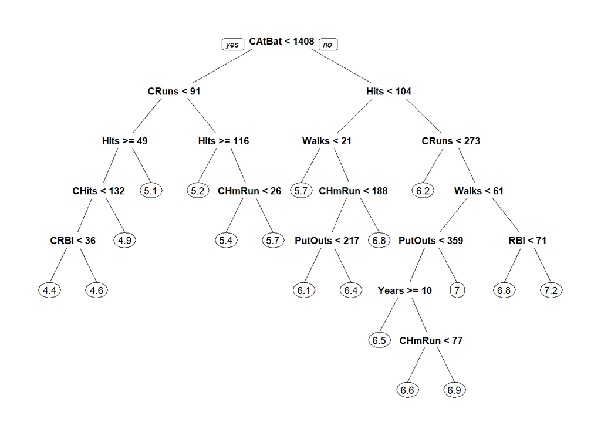

```r
prp(tree_4)
```

```r
tree_4
```

```
## n= 210
##
## node), split, n, deviance, yval
##       * denotes terminal node
##
##   1) root 210 173.7064000 5.940042
##     2) CAtBat< 1407.5 82  26.5274500 5.034419
##       4) CRuns< 91 43  12.4548200 4.693878
##         8) Hits>=48.5 35   2.3498540 4.597758
##          16) CHits< 132 26   0.8021110 4.489206
##            32) CRBI< 35.5 13   0.1965481 4.361733 *
##            33) CRBI>=35.5 13   0.1830791 4.616679 *
##          17) CHits>=132 9   0.3563017 4.911352 *
##         9) Hits< 48.5 8   8.3668560 5.114404 *
##       5) CRuns>=91 39   3.5879350 5.409887
##        10) Hits>=116 14   0.4780928 5.176258 *
##        11) Hits< 116 25   1.9177660 5.540719
##          22) CHmRun< 25.5 12   0.5450096 5.353656 *
##          23) CHmRun>=25.5 13   0.5652409 5.713392 *
##     3) CAtBat>=1407.5 128  36.8427400 6.520207
##       6) Hits< 103.5 44  11.0022300 6.169578
##        12) Walks< 21 12   2.8676730 5.744271 *
##        13) Walks>=21 32   5.1499400 6.329068
##          26) CHmRun< 187.5 25   2.8350310 6.208049
##            52) PutOuts< 216.5 14   1.3070350 6.055854 *
##            53) PutOuts>=216.5 11   0.7909823 6.401752 *
##          27) CHmRun>=187.5 7   0.6411403 6.761277 *
##       7) Hits>=103.5 84  17.5976400 6.703869
##        14) CRuns< 272.5 17   1.1898160 6.218253 *
##        15) CRuns>=272.5 67  11.3816300 6.827085
##          30) Walks< 60.5 41   4.5512330 6.682529
##            60) PutOuts< 359 34   2.9843810 6.616754
##             120) Years>=9.5 14   1.4773440 6.468909 *
##             121) Years< 9.5 20   0.9868150 6.720246
##               242) CHmRun< 76.5 11   0.1938905 6.603184 *
##               243) CHmRun>=76.5 9   0.4579547 6.863320 *
##            61) PutOuts>=359 7   0.7052908 7.002008 *
##          31) Walks>=60.5 26   4.6226030 7.055039
##            62) RBI< 70.5 9   0.9302677 6.811350 *
##            63) RBI>=70.5 17   2.8749270 7.184051 *
```

Which cp gives minimum Errors in Train dataset?

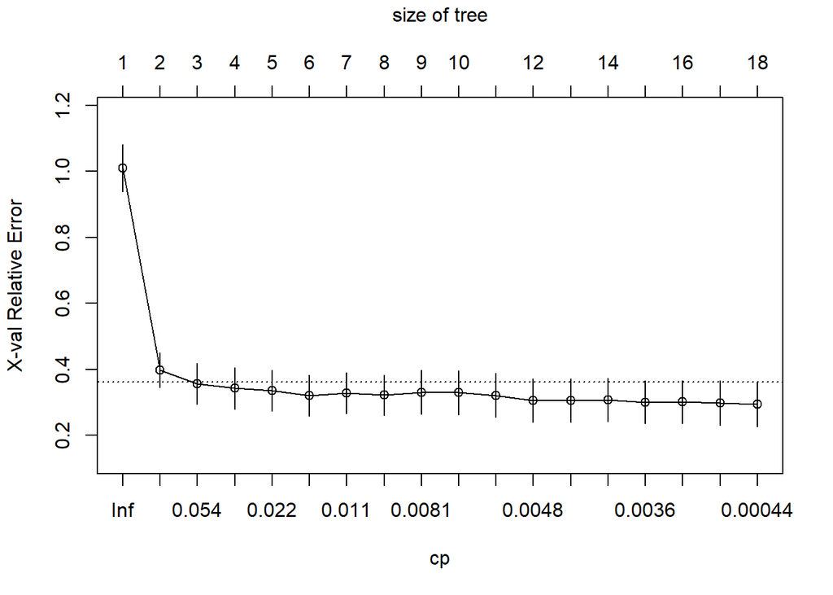

```r
plotcp(tree_4)
```

```r
tree_4$cptable
```

```
##             CP nsplit rel error    xerror       xstd
## 1  0.635188003      0 1.0000000 1.0096751 0.07189533
## 2  0.060358742      1 0.3648120 0.3972993 0.05248767
## 3  0.047452865      2 0.3044533 0.3558762 0.06232516
## 4  0.028935009      3 0.2570004 0.3419235 0.06269917
## 5  0.017181937      4 0.2280654 0.3356142 0.06178890
## 6  0.012709902      5 0.2108834 0.3204350 0.06240402
## 7  0.010006001      6 0.1981735 0.3278477 0.06199094
## 8  0.009635615      7 0.1881675 0.3214369 0.06163773
## 9  0.006862594      8 0.1785319 0.3299279 0.06653377
## 10 0.006858938      9 0.1716693 0.3287427 0.06657785
## 11 0.004959870     10 0.1648104 0.3208566 0.06657308
## 12 0.004705688     11 0.1598505 0.3059058 0.06550211
## 13 0.004648735     12 0.1551448 0.3054565 0.06551007
## 14 0.004242870     13 0.1504961 0.3064506 0.06553970
## 15 0.002994835     14 0.1462532 0.3002764 0.06531215
## 16 0.002432172     15 0.1432584 0.3007804 0.06543856
## 17 0.001928368     16 0.1408262 0.2973107 0.06771004
## 18 0.000100000     17 0.1388979 0.2940253 0.06756731
```

```r
tree_4$cptable[which.min(tree_4$cptable[,'xerror'])]
```

```
## [1] 1e-04
```

Prune the complex Tree

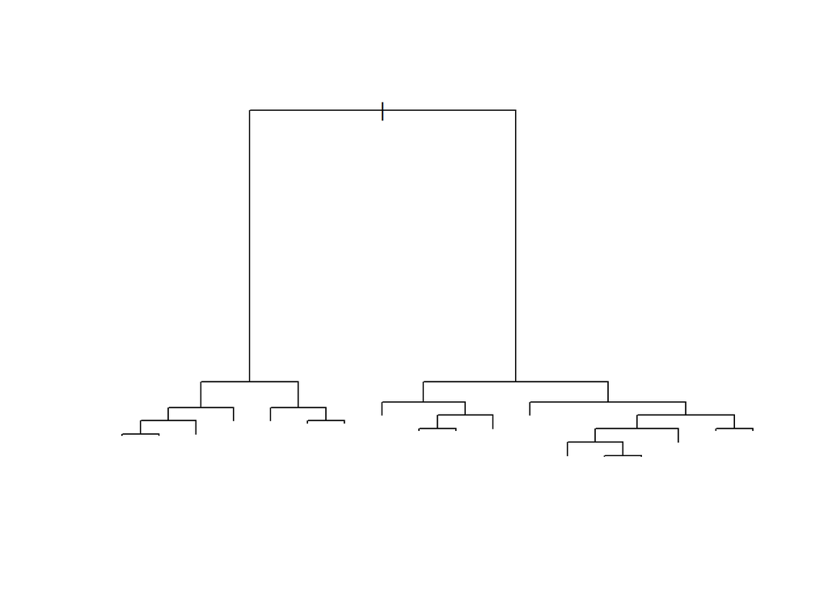

```r
tree_5 <- prune.rpart(tree_4, cp = tree_4$cptable[which.min(tree_4$cptable[,'xerror'])])  # prune tree_4 base on optimum cp
plot(tree_5)
```

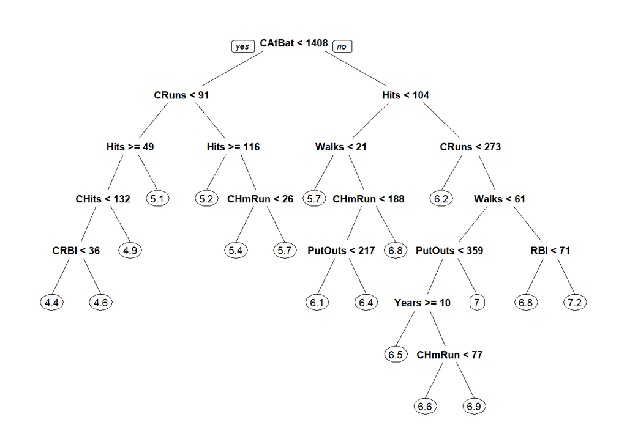

```r
prp(tree_5)
```

```r
tree_5
```

```
## n= 210
##
## node), split, n, deviance, yval
##       * denotes terminal node
##
##   1) root 210 173.7064000 5.940042
##     2) CAtBat< 1407.5 82  26.5274500 5.034419
##       4) CRuns< 91 43  12.4548200 4.693878
##         8) Hits>=48.5 35   2.3498540 4.597758
##          16) CHits< 132 26   0.8021110 4.489206
##            32) CRBI< 35.5 13   0.1965481 4.361733 *
##            33) CRBI>=35.5 13   0.1830791 4.616679 *
##          17) CHits>=132 9   0.3563017 4.911352 *
##         9) Hits< 48.5 8   8.3668560 5.114404 *
##       5) CRuns>=91 39   3.5879350 5.409887
##        10) Hits>=116 14   0.4780928 5.176258 *
##        11) Hits< 116 25   1.9177660 5.540719
##          22) CHmRun< 25.5 12   0.5450096 5.353656 *
##          23) CHmRun>=25.5 13   0.5652409 5.713392 *
##     3) CAtBat>=1407.5 128  36.8427400 6.520207
##       6) Hits< 103.5 44  11.0022300 6.169578
##        12) Walks< 21 12   2.8676730 5.744271 *
##        13) Walks>=21 32   5.1499400 6.329068
##          26) CHmRun< 187.5 25   2.8350310 6.208049
##            52) PutOuts< 216.5 14   1.3070350 6.055854 *
##            53) PutOuts>=216.5 11   0.7909823 6.401752 *
##          27) CHmRun>=187.5 7   0.6411403 6.761277 *
##       7) Hits>=103.5 84  17.5976400 6.703869
##        14) CRuns< 272.5 17   1.1898160 6.218253 *
##        15) CRuns>=272.5 67  11.3816300 6.827085
##          30) Walks< 60.5 41   4.5512330 6.682529
##            60) PutOuts< 359 34   2.9843810 6.616754
##             120) Years>=9.5 14   1.4773440 6.468909 *
##             121) Years< 9.5 20   0.9868150 6.720246
##               242) CHmRun< 76.5 11   0.1938905 6.603184 *
##               243) CHmRun>=76.5 9   0.4579547 6.863320 *
##            61) PutOuts>=359 7   0.7052908 7.002008 *
##          31) Walks>=60.5 26   4.6226030 7.055039
##            62) RBI< 70.5 9   0.9302677 6.811350 *
##            63) RBI>=70.5 17   2.8749270 7.184051 *
```

## 7.4 Model 8: Bagging

```r
set.seed(1234)
bagging_1 <- randomForest(Log_Salary ~ . - Salary, mtry = ncol(train) - 2, ntree = 500, data = train)

bagging_1
```

```
##
## Call:
##  randomForest(formula = Log_Salary ~ . - Salary, data = train,      mtry = ncol(train) - 2, ntree = 500)
##                Type of random forest: regression
##                      Number of trees: 500
## No. of variables tried at each split: 18
##
##           Mean of squared residuals: 0.193834
##                     % Var explained: 76.57
```

- Each Tree uses 18 variables
- Makes 500 different Trees
- MSE: 0.193834
- R<sup>2</sup>: 0.7657 (76.57% of variance has been explained by this model)

## 7.5 Model 9: Random Forest

```r
set.seed(1234)
rf_1 <- randomForest(Log_Salary ~ . - Salary, data = train, mtry = 6, ntree = 500, importance = T)

rf_1
```

```
##
## Call:
##  randomForest(formula = Log_Salary ~ . - Salary, data = train,      mtry = 6, ntree = 500, importance = T)
##                Type of random forest: regression
##                      Number of trees: 500
## No. of variables tried at each split: 6
##
##           Mean of squared residuals: 0.1838468
##                     % Var explained: 77.77
```

- Each Tree uses 6 variables
- 500 different Trees have been made
- R<sup>2</sup>: 0.7777 (77.77% of variance has been explained by this model)

```r
importance(rf_1)
```

```
##              %IncMSE IncNodePurity
## Hits      12.0788272     6.4617496
## HmRun      1.9981734     2.1736033
## Runs      10.1901269     4.6760844
## RBI        3.8828640     5.8155169
## Walks      8.2240312     5.2860428
## Years     11.8825880     4.0072295
## CAtBat    16.4731433    38.6594069
## CHits     15.6924882    32.4255776
## CHmRun     9.2016446     5.5977725
## CRuns     15.0303745    27.1678870
## CRBI      10.3885271    19.1551688
## CWalks     9.2827965    14.1343759
## League     0.6674438     0.2290537
## Division  -0.2110318     0.1893184
## PutOuts    4.1320128     2.4530714
## Assists    1.4535136     1.1397716
## Errors     2.1159946     1.2697635
## NewLeague  0.5877382     0.3394984
```

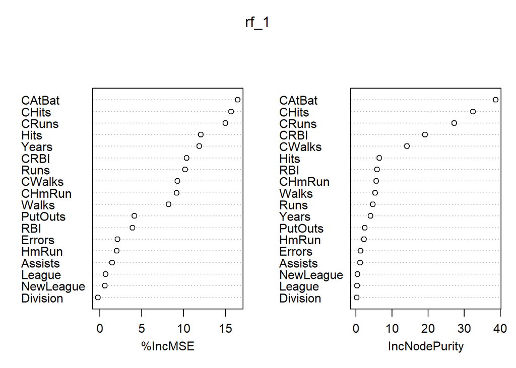

```r
varImpPlot(rf_1)
```

> **CAtBat** has the most impact on increasing MSE if we remove it from the model -> the most important variable

k-fold cross-validation for feature selection

```r
set.seed(12345)
rf_cv <- rfcv(train[, -c(18, 20)], train$Log_Salary, cv.fold = 10, step = 0.75, mtry = function(p) max(1, floor(sqrt(p))), recursive = F)
class(rf_cv)
```

```
## [1] "list"
```

```r
str(rf_cv)
```

```
## List of 3
##  $ n.var    : num [1:9] 18 14 10 8 6 4 3 2 1
##  $ error.cv : Named num [1:9] 0.175 0.178 0.172 0.185 0.207 ...
##   ..- attr(*, "names")= chr [1:9] "18" "14" "10" "8" ...
##  $ predicted:List of 9
##   ..$ 18: num [1:210] 5.6 6.27 6.49 6.59 4.87 ...
##   ..$ 14: num [1:210] 5.62 6.31 6.48 6.53 4.88 ...
##   ..$ 10: num [1:210] 5.63 6.32 6.45 6.49 4.85 ...
##   ..$ 8 : num [1:210] 5.63 6.23 6.37 6.51 4.88 ...
##   ..$ 6 : num [1:210] 5.63 6.12 6.51 6.56 4.88 ...
##   ..$ 4 : num [1:210] 5.48 6.05 6.52 6.36 4.87 ...
##   ..$ 3 : num [1:210] 5.47 6.69 6.56 6.27 4.91 ...
##   ..$ 2 : num [1:210] 5.54 6.54 6.71 6.59 4.95 ...
##   ..$ 1 : num [1:210] 5.87 6.55 6.86 6.73 5 ...
```

```r
rf_cv$n.var  # vector of number of variables of 'Variables Pool' at each step
```

```
## [1] 18 14 10  8  6  4  3  2  1
```

```r
rf_cv$error.cv  # vector of MSEs at each step by each 'Variables Pool'
```

```
##        18        14        10         8         6         4         3         2
## 0.1748361 0.1775350 0.1724472 0.1853353 0.2073023 0.2432372 0.2549849 0.2664398
##         1
## 0.3373662
```

```r
which.min(rf_cv$error.cv)
```

```
## 10
##  3
```

> best ‘Variables Pool’ has 10 variables

Remove 8 less important variables base on ‘relative importance-variables table’

```r
sort(importance(rf_1)[,1], decreasing = T)
```

```
##     CAtBat      CHits      CRuns       Hits      Years       CRBI       Runs
## 16.4731433 15.6924882 15.0303745 12.0788272 11.8825880 10.3885271 10.1901269
##     CWalks     CHmRun      Walks    PutOuts        RBI     Errors      HmRun
##  9.2827965  9.2016446  8.2240312  4.1320128  3.8828640  2.1159946  1.9981734
##    Assists     League  NewLeague   Division
##  1.4535136  0.6674438  0.5877382 -0.2110318
```

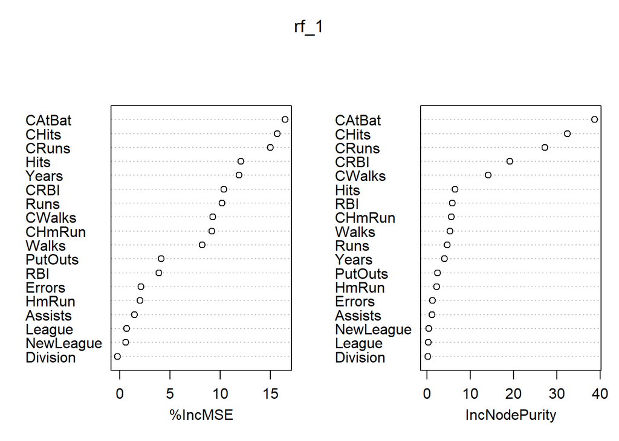

```r
varImpPlot(rf_1)
```

```r
reg_formula <- as.formula(Log_Salary ~ CAtBat + CHits + CRuns + Hits + Years + CRBI + Runs + CWalks + CHmRun + Walks)  # pool of 10 main important variables

floor(sqrt(10))  # use maximum 3 variable for every tree in RandomForest
```

```
## [1] 3
```

Make the optimum model base on k-fold result

```r
set.seed(1234)
rf_2 <- randomForest(reg_formula, data = train, mtry = floor(sqrt(10)), ntree = 500)
rf_2
```

```
##
## Call:
##  randomForest(formula = reg_formula, data = train, mtry = floor(sqrt(10)),      ntree = 500)
##                Type of random forest: regression
##                      Number of trees: 500
## No. of variables tried at each split: 3
##
##           Mean of squared residuals: 0.1757252
##                     % Var explained: 78.76
```

> R<sup>2</sup>: 0.7876 (78.76% of variance has been explained by this model)

# 8 Model Evaluation

## 8.1 Test the Model 5 performance

### 8.1.1 Prediction

Create model matrix for Test dataset

```r
test$Log_Salary <- log(test$Salary)

x_test <- model.matrix(Log_Salary ~ . - Salary, data = test)[,-1]  # remove intercept

pred_ridgereg <- predict(ridgereg_2, s = ridge_cv$lambda.min, newx = x_test)  # prediction on test dataset
pred_ridgereg  # predictions of Log_Salary
```

```
##           s1
## 2   5.980212
## 6   6.246058
## 14  5.369621
## 18  4.891656
## 28  6.049935
## 32  5.429584
## 41  4.993450
## 46  5.321466
## 59  5.853761
## 60  6.637729
## 61  5.468912
## 66  7.404465
## 71  6.675388
## 79  5.687971
```

[output cut: 39 more lines]

```r
pred_ridgereg <- exp(pred_ridgereg)
pred_ridgereg  # predictions of Salary
```

```
##            s1
## 2    395.5243
## 6    515.9746
## 14   214.7815
## 18   133.1739
## 28   424.0853
## 32   228.0544
## 41   147.4442
## 46   204.6838
## 59   348.5429
## 60   763.3594
## 61   237.2019
## 66  1643.3061
## 71   792.6553
## 79   295.2938
```

[output cut: 39 more lines]

### 8.1.2 Evaluate model performance in Test dataset:

Actual vs. Prediction

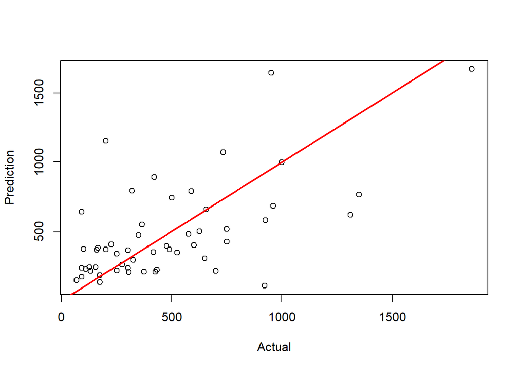

```r
plot(test$Salary, pred_ridgereg, xlab = "Actual", ylab = "Prediction")
abline(a = 0, b = 1, col = "red", lwd = 2)  # compare with 45' line
```

Absolute Error mean, median, sd, max, min

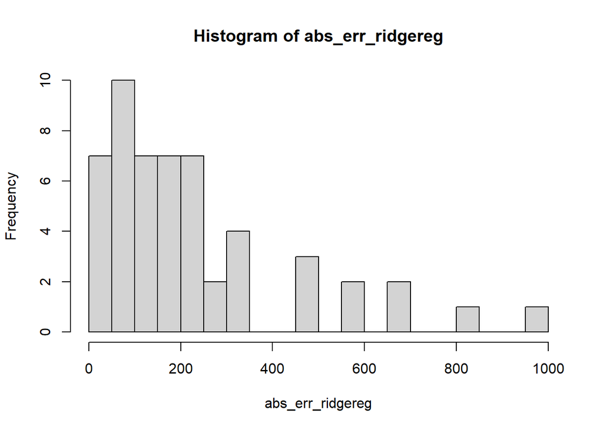

```r
abs_err_ridgereg <- abs(pred_ridgereg - test$Salary) #absolute value (AEV)

hist(abs_err_ridgereg, breaks = 25)  # residuals distribution
```

```r
mean(abs_err_ridgereg)
```

```
## [1] 230.0146
```

```r
median(abs_err_ridgereg)
```

```
## [1] 178.6634
```

```r
sd(abs_err_ridgereg)
```

```
## [1] 214.7508
```

```r
max(abs_err_ridgereg)
```

```
## [1] 953.5754
```

```r
min(abs_err_ridgereg)
```

```
## [1] 1.764183
```

Boxplot (which observations are outliers?)

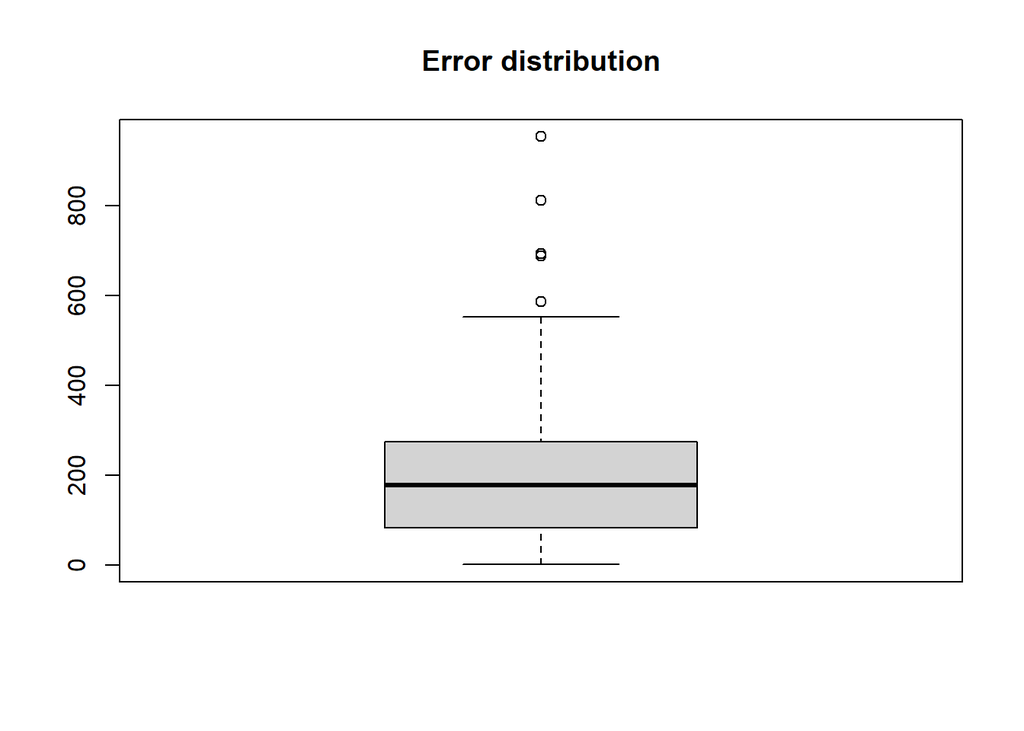

```r
boxplot(abs_err_ridgereg, main = 'Error distribution')
```

```r
models_comp <- rbind(models_comp, "RidgeReg" = c(mean(abs_err_ridgereg),
                                                 median(abs_err_ridgereg),
                                                 sd(abs_err_ridgereg),
                                                 IQR(abs_err_ridgereg),
                                                 range(abs_err_ridgereg)))

models_comp
```

|  | Mean.of.AbsErrors | Median.of.AbsErrors | SD.of.AbsErrors | IQR.of.AbsErrors | Min.of.AbsErrors | Max.of.AbsErrors |
| --- | --- | --- | --- | --- | --- | --- |
| LM | 237.4351 | 182.5055 | 220.8587 | 255.3140 | 0.08237289 | 831.5086 |
| BestSub | 246.9167 | 181.9413 | 237.4687 | 207.2769 | 0.90210710 | 945.0831 |
| BestSubCV | 233.5006 | 169.5449 | 233.3134 | 177.0159 | 2.31135988 | 935.5373 |
| TrimmedBestSub | 242.5957 | 172.5117 | 235.7795 | 252.5046 | 2.14943889 | 847.3258 |
| RidgeReg | 230.0146 | 178.6634 | 214.7508 | 191.2145 | 1.76418297 | 953.5754 |

## 8.2 Test the Model 6 performance

### 8.2.1 Prediction

```r
pred_lassoreg <- predict(lassoreg_2, s = lasso_cv$lambda.min, newx = x_test)  # prediction on test dataset
pred_lassoreg  # predictions of Log_Salary
```

```
##           s1
## 2   6.163232
## 6   6.444350
## 14  5.333987
## 18  4.826670
## 28  6.217287
## 32  5.440826
## 41  4.890032
## 46  5.338009
## 59  5.932556
## 60  6.585616
## 61  5.389989
## 66  7.367423
## 71  6.708095
## 79  5.666142
```

[output cut: 39 more lines]

```r
pred_lassoreg <- exp(pred_lassoreg)
pred_lassoreg  # predictions of Salary
```

```
##             s1
## 2    474.96082
## 6    629.13768
## 14   207.26278
## 18   124.79469
## 28   501.34121
## 32   230.63251
## 41   132.95785
## 46   208.09804
## 59   377.11731
## 60   724.59743
## 61   219.20094
## 66  1583.54809
## 71   819.00856
## 79   288.91762
```

[output cut: 39 more lines]

### 8.2.2 Evaluate model performance in Test dataset:

Actual vs. Prediction

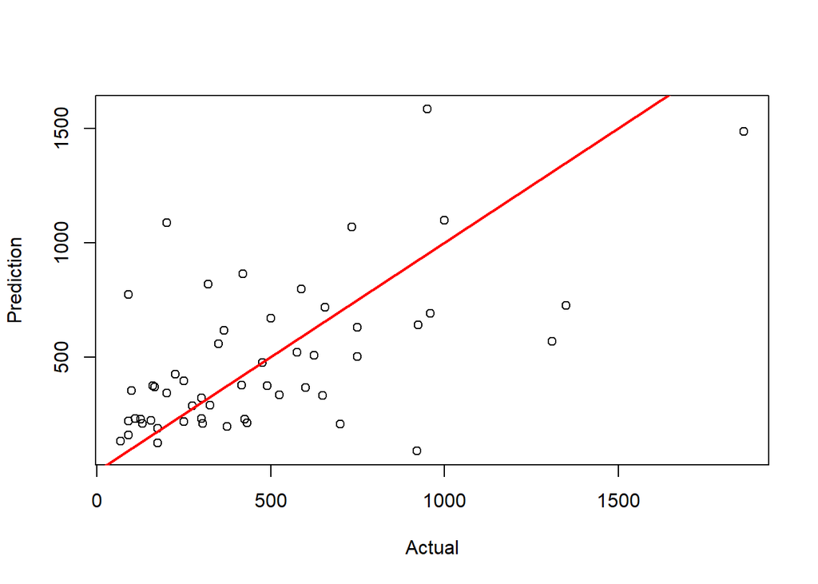

```r
plot(test$Salary, pred_lassoreg, xlab = "Actual", ylab = "Prediction")
abline(a = 0, b = 1, col = "red", lwd = 2)  # compare with 45' line
```

Absolute Error mean, median, sd, max, min

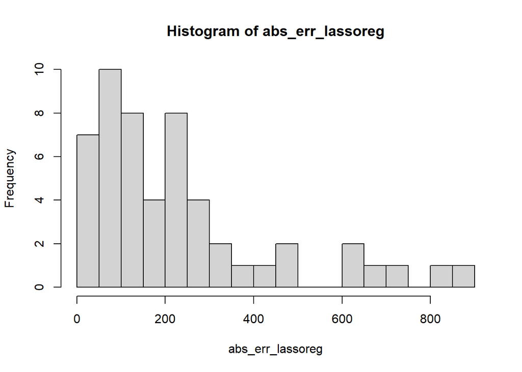

```r
abs_err_lassoreg <- abs(pred_lassoreg - test$Salary) #absolute value (AEV)

hist(abs_err_lassoreg, breaks = 25)  # residuals distribution
```

```r
mean(abs_err_lassoreg)
```

```
## [1] 231.3022
```

```r
median(abs_err_lassoreg)
```

```
## [1] 177.9803
```

```r
sd(abs_err_lassoreg)
```

```
## [1] 217.9866
```

```r
max(abs_err_lassoreg)
```

```
## [1] 886.5195
```

```r
min(abs_err_lassoreg)
```

```
## [1] 0.03918264
```

Boxplot (which observations are outliers?)

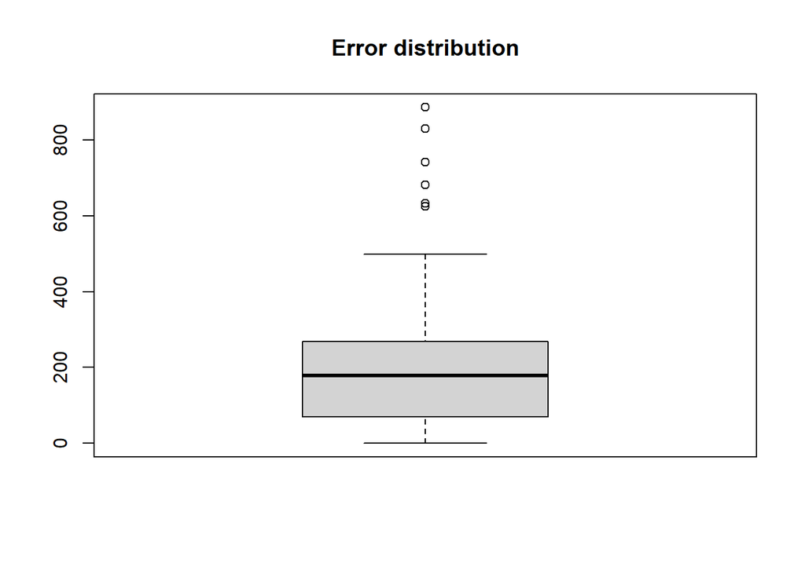

```r
boxplot(abs_err_lassoreg, main = 'Error distribution')
```

```r
models_comp <- rbind(models_comp, "LassoReg" = c(mean(abs_err_lassoreg),
                                                 median(abs_err_lassoreg),
                                                 sd(abs_err_lassoreg),
                                                 IQR(abs_err_lassoreg),
                                                 range(abs_err_lassoreg)))

models_comp
```

|  | Mean.of.AbsErrors | Median.of.AbsErrors | SD.of.AbsErrors | IQR.of.AbsErrors | Min.of.AbsErrors | Max.of.AbsErrors |
| --- | --- | --- | --- | --- | --- | --- |
| LM | 237.4351 | 182.5055 | 220.8587 | 255.3140 | 0.08237289 | 831.5086 |
| BestSub | 246.9167 | 181.9413 | 237.4687 | 207.2769 | 0.90210710 | 945.0831 |
| BestSubCV | 233.5006 | 169.5449 | 233.3134 | 177.0159 | 2.31135988 | 935.5373 |
| TrimmedBestSub | 242.5957 | 172.5117 | 235.7795 | 252.5046 | 2.14943889 | 847.3258 |
| RidgeReg | 230.0146 | 178.6634 | 214.7508 | 191.2145 | 1.76418297 | 953.5754 |
| LassoReg | 231.3022 | 177.9803 | 217.9866 | 198.7564 | 0.03918264 | 886.5195 |

## 8.3 Test the Model 7 performance

### 8.3.1 Prediction

```r
pred_tree <- predict(tree_5, test)  # prediction on test dataset
pred_tree  # predictions of Log_Salary
```

```
##        2        6       14       18       28       32       41       46
## 6.401752 6.468909 6.055854 5.114404 6.218253 4.911352 5.114404 5.353656
##       59       60       61       66       71       79       86       91
## 5.744271 7.184051 4.616679 7.184051 6.055854 6.055854 6.401752 5.744271
##       97       99      100      103      121      122      135      136
## 7.184051 5.713392 6.603184 5.353656 6.761277 6.761277 5.114404 5.114404
##      147      160      162      165      166      179      181      183
## 6.055854 6.218253 6.603184 6.055854 4.911352 6.468909 7.184051 6.218253
##      184      188      192      197      201      203      212      240
## 4.616679 6.218253 6.055854 6.468909 7.184051 6.218253 6.401752 4.361733
##      242      273      283      288      290      292      294      296
## 5.713392 6.218253 7.002008 6.218253 4.911352 5.713392 6.811350 5.114404
##      307      310      312      316      321
## 5.744271 5.176258 6.055854 4.911352 6.811350
```

```r
pred_tree <- exp(pred_tree)
pred_tree  # predictions of Salary
```

```
##          2          6         14         18         28         32         41
##  602.90035  644.78018  426.60325  166.40158  501.82586  135.82287  166.40158
##         46         59         60         61         66         71         79
##  211.37977  312.39592 1318.23758  101.15751 1318.23758  426.60325  426.60325
##         86         91         97         99        100        103        121
##  602.90035  312.39592 1318.23758  302.89664  737.43973  211.37977  863.74421
##        122        135        136        147        160        162        165
##  863.74421  166.40158  166.40158  426.60325  501.82586  737.43973  426.60325
##        166        179        181        183        184        188        192
##  135.82287  644.78018 1318.23758  501.82586  101.15751  501.82586  426.60325
##        197        201        203        212        240        242        273
##  644.78018 1318.23758  501.82586  602.90035   78.39285  302.89664  501.82586
##        283        288        290        292        294        296        307
## 1098.83704  501.82586  135.82287  302.89664  908.09593  166.40158  312.39592
##        310        312        316        321
##  177.01921  426.60325  135.82287  908.09593
```

### 8.3.2 Evaluate model performance in Test dataset:

Actual vs. Prediction

```r
plot(test$Salary, pred_tree, xlab = "Actual", ylab = "Prediction")
abline(a = 0, b = 1, col = "red", lwd = 2)  # compare with 45' line
```

[output not shown]

Absolute Error mean, median, sd, max, min

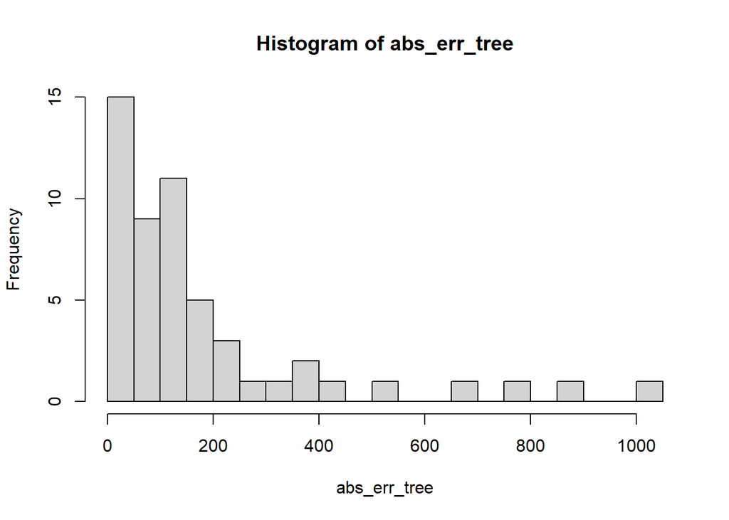

```r
abs_err_tree <- abs(pred_tree - test$Salary) #absolute value (AEV)

hist(abs_err_tree, breaks = 25)  # residuals distribution
```

```r
mean(abs_err_tree)
```

```
## [1] 175.959
```

```r
median(abs_err_tree)
```

```
## [1] 105.2198
```

```r
sd(abs_err_tree)
```

```
## [1] 223.3094
```

```r
max(abs_err_tree)
```

```
## [1] 1008.837
```

```r
min(abs_err_tree)
```

```
## [1] 2.896645
```

Boxplot (which observations are outliers?)

```r
boxplot(abs_err_tree, main = 'Error distribution')
```

[output not shown]

```r
models_comp <- rbind(models_comp, "Tree" = c(mean(abs_err_tree),
                                                 median(abs_err_tree),
                                                 sd(abs_err_tree),
                                                 IQR(abs_err_tree),
                                                 range(abs_err_tree)))

models_comp
```

|  | Mean.of.AbsErrors | Median.of.AbsErrors | SD.of.AbsErrors | IQR.of.AbsErrors | Min.of.AbsErrors | Max.of.AbsErrors |
| --- | --- | --- | --- | --- | --- | --- |
| LM | 237.4351 | 182.5055 | 220.8587 | 255.3140 | 0.08237289 | 831.5086 |
| BestSub | 246.9167 | 181.9413 | 237.4687 | 207.2769 | 0.90210710 | 945.0831 |
| BestSubCV | 233.5006 | 169.5449 | 233.3134 | 177.0159 | 2.31135988 | 935.5373 |
| TrimmedBestSub | 242.5957 | 172.5117 | 235.7795 | 252.5046 | 2.14943889 | 847.3258 |
| RidgeReg | 230.0146 | 178.6634 | 214.7508 | 191.2145 | 1.76418297 | 953.5754 |
| LassoReg | 231.3022 | 177.9803 | 217.9866 | 198.7564 | 0.03918264 | 886.5195 |
| Tree | 175.9590 | 105.2198 | 223.3094 | 155.8417 | 2.89664460 | 1008.8370 |

### 8.4.1 Prediction

```r
pred_bagging <- predict(tree_5, test)  # prediction on test dataset
pred_bagging  # predictions of Log_Salary
```

```
##        2        6       14       18       28       32       41       46
## 6.401752 6.468909 6.055854 5.114404 6.218253 4.911352 5.114404 5.353656
##       59       60       61       66       71       79       86       91
## 5.744271 7.184051 4.616679 7.184051 6.055854 6.055854 6.401752 5.744271
##       97       99      100      103      121      122      135      136
## 7.184051 5.713392 6.603184 5.353656 6.761277 6.761277 5.114404 5.114404
##      147      160      162      165      166      179      181      183
## 6.055854 6.218253 6.603184 6.055854 4.911352 6.468909 7.184051 6.218253
##      184      188      192      197      201      203      212      240
## 4.616679 6.218253 6.055854 6.468909 7.184051 6.218253 6.401752 4.361733
##      242      273      283      288      290      292      294      296
## 5.713392 6.218253 7.002008 6.218253 4.911352 5.713392 6.811350 5.114404
##      307      310      312      316      321
## 5.744271 5.176258 6.055854 4.911352 6.811350
```

```r
pred_bagging <- exp(pred_bagging)
pred_bagging  # predictions of Salary
```

```
##          2          6         14         18         28         32         41
##  602.90035  644.78018  426.60325  166.40158  501.82586  135.82287  166.40158
##         46         59         60         61         66         71         79
##  211.37977  312.39592 1318.23758  101.15751 1318.23758  426.60325  426.60325
##         86         91         97         99        100        103        121
##  602.90035  312.39592 1318.23758  302.89664  737.43973  211.37977  863.74421
##        122        135        136        147        160        162        165
##  863.74421  166.40158  166.40158  426.60325  501.82586  737.43973  426.60325
##        166        179        181        183        184        188        192
##  135.82287  644.78018 1318.23758  501.82586  101.15751  501.82586  426.60325
##        197        201        203        212        240        242        273
##  644.78018 1318.23758  501.82586  602.90035   78.39285  302.89664  501.82586
##        283        288        290        292        294        296        307
## 1098.83704  501.82586  135.82287  302.89664  908.09593  166.40158  312.39592
##        310        312        316        321
##  177.01921  426.60325  135.82287  908.09593
```

### 8.4.2 Evaluate model performance in Test dataset:

Actual vs. Prediction

```r
plot(test$Salary, pred_bagging, xlab = "Actual", ylab = "Prediction")
abline(a = 0, b = 1, col = "red", lwd = 2)  # compare with 45' line
```

[output not shown]

Absolute Error mean, median, sd, max, min

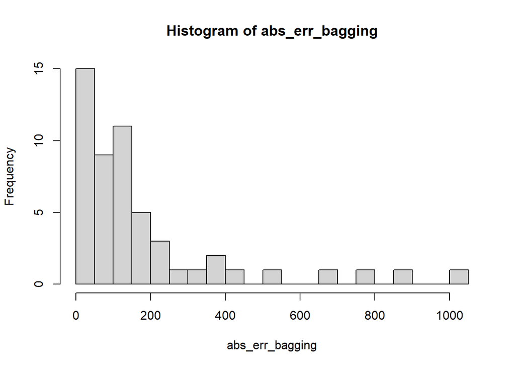

```r
abs_err_bagging <- abs(pred_bagging - test$Salary) #absolute value (AEV)

hist(abs_err_bagging, breaks = 25)  # residuals distribution
```

```r
mean(abs_err_bagging)
```

```
## [1] 175.959
```

```r
median(abs_err_bagging)
```

```
## [1] 105.2198
```

```r
sd(abs_err_bagging)
```

```
## [1] 223.3094
```

```r
max(abs_err_bagging)
```

```
## [1] 1008.837
```

```r
min(abs_err_bagging)
```

```
## [1] 2.896645
```

Boxplot (which observations are outliers?)

```r
boxplot(abs_err_bagging, main = 'Error distribution')
```

[output not shown]

```r
models_comp <- rbind(models_comp, "Bagging" = c(mean(abs_err_bagging),
                                                 median(abs_err_bagging),
                                                 sd(abs_err_bagging),
                                                 IQR(abs_err_bagging),
                                                 range(abs_err_bagging)))

models_comp
```

|  | Mean.of.AbsErrors | Median.of.AbsErrors | SD.of.AbsErrors | IQR.of.AbsErrors | Min.of.AbsErrors | Max.of.AbsErrors |
| --- | --- | --- | --- | --- | --- | --- |
| LM | 237.4351 | 182.5055 | 220.8587 | 255.3140 | 0.08237289 | 831.5086 |
| BestSub | 246.9167 | 181.9413 | 237.4687 | 207.2769 | 0.90210710 | 945.0831 |
| BestSubCV | 233.5006 | 169.5449 | 233.3134 | 177.0159 | 2.31135988 | 935.5373 |
| TrimmedBestSub | 242.5957 | 172.5117 | 235.7795 | 252.5046 | 2.14943889 | 847.3258 |
| RidgeReg | 230.0146 | 178.6634 | 214.7508 | 191.2145 | 1.76418297 | 953.5754 |
| LassoReg | 231.3022 | 177.9803 | 217.9866 | 198.7564 | 0.03918264 | 886.5195 |
| Tree | 175.9590 | 105.2198 | 223.3094 | 155.8417 | 2.89664460 | 1008.8370 |
| Bagging | 175.9590 | 105.2198 | 223.3094 | 155.8417 | 2.89664460 | 1008.8370 |

### 8.5.1 Prediction

```r
pred_rf <- predict(tree_5, test)  # prediction on test dataset
pred_rf  # predictions of Log_Salary
```

```
##        2        6       14       18       28       32       41       46
## 6.401752 6.468909 6.055854 5.114404 6.218253 4.911352 5.114404 5.353656
##       59       60       61       66       71       79       86       91
## 5.744271 7.184051 4.616679 7.184051 6.055854 6.055854 6.401752 5.744271
##       97       99      100      103      121      122      135      136
## 7.184051 5.713392 6.603184 5.353656 6.761277 6.761277 5.114404 5.114404
##      147      160      162      165      166      179      181      183
## 6.055854 6.218253 6.603184 6.055854 4.911352 6.468909 7.184051 6.218253
##      184      188      192      197      201      203      212      240
## 4.616679 6.218253 6.055854 6.468909 7.184051 6.218253 6.401752 4.361733
##      242      273      283      288      290      292      294      296
## 5.713392 6.218253 7.002008 6.218253 4.911352 5.713392 6.811350 5.114404
##      307      310      312      316      321
## 5.744271 5.176258 6.055854 4.911352 6.811350
```

```r
pred_rf <- exp(pred_rf)
pred_rf  # predictions of Salary
```

```
##          2          6         14         18         28         32         41
##  602.90035  644.78018  426.60325  166.40158  501.82586  135.82287  166.40158
##         46         59         60         61         66         71         79
##  211.37977  312.39592 1318.23758  101.15751 1318.23758  426.60325  426.60325
##         86         91         97         99        100        103        121
##  602.90035  312.39592 1318.23758  302.89664  737.43973  211.37977  863.74421
##        122        135        136        147        160        162        165
##  863.74421  166.40158  166.40158  426.60325  501.82586  737.43973  426.60325
##        166        179        181        183        184        188        192
##  135.82287  644.78018 1318.23758  501.82586  101.15751  501.82586  426.60325
##        197        201        203        212        240        242        273
##  644.78018 1318.23758  501.82586  602.90035   78.39285  302.89664  501.82586
##        283        288        290        292        294        296        307
## 1098.83704  501.82586  135.82287  302.89664  908.09593  166.40158  312.39592
##        310        312        316        321
##  177.01921  426.60325  135.82287  908.09593
```

### 8.5.2 Evaluate model performance in Test dataset:

Actual vs. Prediction

```r
plot(test$Salary, pred_rf, xlab = "Actual", ylab = "Prediction")
abline(a = 0, b = 1, col = "red", lwd = 2)  # compare with 45' line
```

[output not shown]

Absolute Error mean, median, sd, max, min

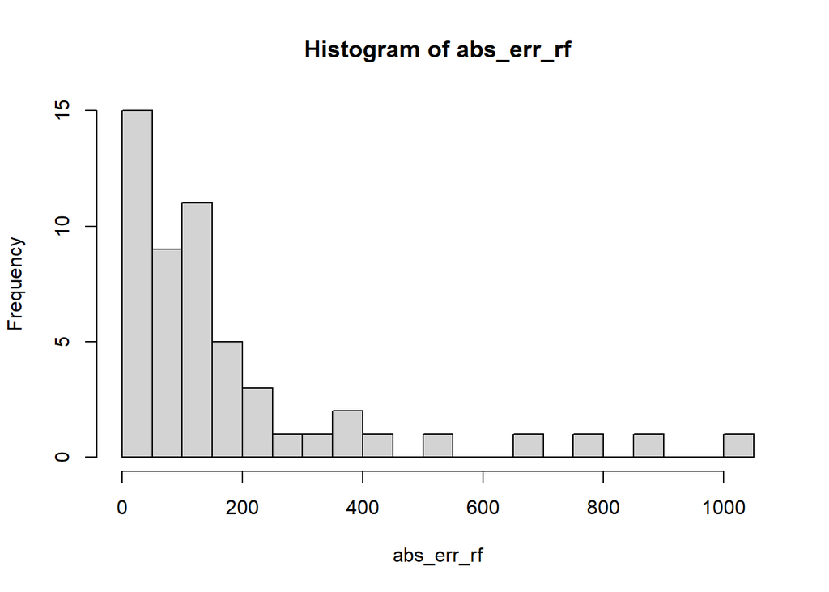

```r
abs_err_rf <- abs(pred_rf - test$Salary) #absolute value (AEV)

hist(abs_err_rf, breaks = 25)  # residuals distribution
```

```r
mean(abs_err_rf)
```

```
## [1] 175.959
```

```r
median(abs_err_rf)
```

```
## [1] 105.2198
```

```r
sd(abs_err_rf)
```

```
## [1] 223.3094
```

```r
max(abs_err_rf)
```

```
## [1] 1008.837
```

```r
min(abs_err_rf)
```

```
## [1] 2.896645
```

Boxplot (which observations are outliers?)

```r
boxplot(abs_err_rf, main = 'Error distribution')
```

[output not shown]

```r
models_comp <- rbind(models_comp, "RandomForest" = c(mean(abs_err_rf),
                                                 median(abs_err_rf),
                                                 sd(abs_err_rf),
                                                 IQR(abs_err_rf),
                                                 range(abs_err_rf)))

models_comp
```

|  | Mean.of.AbsErrors | Median.of.AbsErrors | SD.of.AbsErrors | IQR.of.AbsErrors | Min.of.AbsErrors | Max.of.AbsErrors |
| --- | --- | --- | --- | --- | --- | --- |
| LM | 237.4351 | 182.5055 | 220.8587 | 255.3140 | 0.08237289 | 831.5086 |
| BestSub | 246.9167 | 181.9413 | 237.4687 | 207.2769 | 0.90210710 | 945.0831 |
| BestSubCV | 233.5006 | 169.5449 | 233.3134 | 177.0159 | 2.31135988 | 935.5373 |
| TrimmedBestSub | 242.5957 | 172.5117 | 235.7795 | 252.5046 | 2.14943889 | 847.3258 |
| RidgeReg | 230.0146 | 178.6634 | 214.7508 | 191.2145 | 1.76418297 | 953.5754 |
| LassoReg | 231.3022 | 177.9803 | 217.9866 | 198.7564 | 0.03918264 | 886.5195 |
| Tree | 175.9590 | 105.2198 | 223.3094 | 155.8417 | 2.89664460 | 1008.8370 |
| Bagging | 175.9590 | 105.2198 | 223.3094 | 155.8417 | 2.89664460 | 1008.8370 |
| RandomForest | 175.9590 | 105.2198 | 223.3094 | 155.8417 | 2.89664460 | 1008.8370 |

For more information check the [Github](https://github.com/mamomen1996/R_CS_05) repository.